# New York CitiBike Data Analysis

### I was going to take 99.5 % but data is huge so going with 99% laptop not able to handle

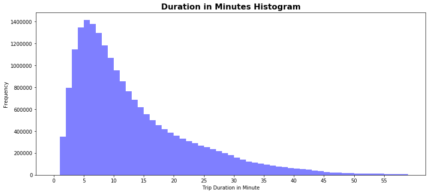

```python
# Creating histogram only for duration in minutes that fall in 99 % percentile that is 60 minutes by taking upper limit.
plt.figure(figsize=(14,6))
bins = np.arange(0, 60, 1)
ticks = np.arange(0, 60, 5)
plt.hist(data=df, x='duration_minutes', bins=bins,color='blue', alpha = .5)
plt.xticks(ticks, ticks)
plt.xlabel('Trip Duration in Minute')
plt.ylabel("Frequency")
plt.title("Duration in Minutes Histogram",fontsize = 16, fontweight = 'bold');
```

```python
df.shape
```

```
(20484980, 22)
```

## Quality 5

```python
# lets include only duration minutes which is in 99.5% interval which 58 -60
df = df[df.duration_minutes <=60]
```

```python
# using shape function to see if records for minutes above 60 are removed
df.shape
```

```
(20292386, 22)
```

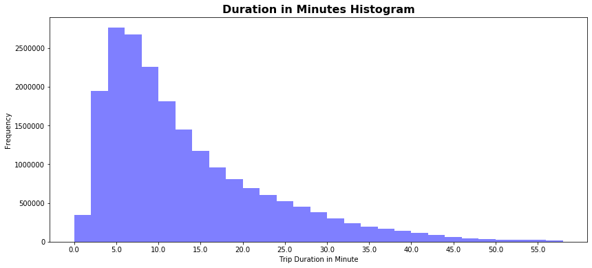

```python
# creating histogram for new minutes column, where minutes is less than 60. It is required to see new distribution after making changes
plt.figure(figsize=(14,6))
bins = np.arange(0, df.duration_minutes.max(), 2)
ticks = np.arange(0, df.duration_minutes.max(), 5)
plt.hist(data=df, x='duration_minutes', bins=bins, color='blue', alpha = .5)
plt.xticks(ticks, ticks);
plt.xlabel('Trip Duration in Minute')
plt.ylabel("Frequency")
plt.title("Duration in Minutes Histogram",fontsize = 16, fontweight = 'bold');
```

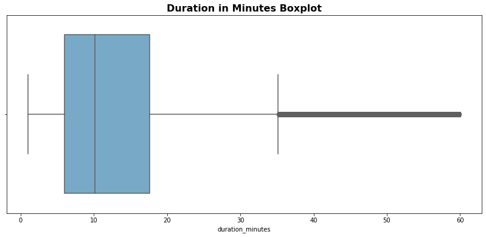

```python
# creating the box plot using seaborn boxplot function to dig deeper into minutes distribution
plt.figure(figsize=(14,6))
ax = sb.boxplot(data = df,x="duration_minutes",palette='Blues')
plt.title("Duration in Minutes Boxplot",fontsize = 16, fontweight = 'bold');
```

```python
# Using Pandas describe method to see if no wrong record where minutes is greater than 60 are included in dataframe
df.duration_minutes.describe(percentiles=[.99])
```

```
count   20292386.00000
mean          13.17073
std            9.80465
min            1.01667
50%           10.15000
99%           45.28333
max           60.00000
Name: duration_minutes, dtype: float64
```

## Assessing Trip Distance colum for cleaning

```python
df.distance_miles.describe()
```

```
count   20292386.00000
mean           1.09807
std            0.86291
min            0.00000
25%            0.51319
50%            0.85093
75%            1.42154
max           10.33926
Name: distance_miles, dtype: float64
```

#### As we can see in above statistics for distance in miles that data has some outliers as 75 5 is 1.4 while max is 10. It may be possible that some rider are using bicycle a lot. But I assume that it can be case where data is reported wrong. Or riders carry the bicycle by car or bus. So I am going to use SPEED as a mojor to remove outliers. As per some articles maximum bicycle for normal rider is 26 miles /hour. So I will make one extra metric named "Speed" to clean data further. This Speed metric will help to remove extra outliers in Duration in minutes if there is any

```python
#let clear minutes based on speed. An Average Human can ycle at 23- 26 miles per hour
```

```python
# creating speed column in dataframe for Speed in Miles per hour. This column is a new feature indetified by me for better analysis
df['speed']= df.distance_miles/((df.duration_minutes)/60)
```

```python
# checking statistics for speed column.
df['speed'].describe()
```

```
count   20292386.00000
mean           5.49772
std            2.05154
min            0.00000
25%            4.38651
50%            5.61344
75%            6.79407
max          109.93951
Name: speed, dtype: float64
```

### In above code we have seen that the maximum speed is 109 miles per hour which is not possible. Considering maximum speed to be 26 miles per hour based on [road-bike-uk](https://www.road-bike.co.uk/articles/average-speed.php)

```python
# checking column where speed greater than 26 miles per hour
df[df['speed'] > 26]
```

|  | tripduration | starttime | stoptime | start_station_id | start_station_name | start_station_latitude | start_station_longitude | end_station_id | end_station_name | end_station_latitude | ... | birth_year | gender | distance_miles | start_date | month | day | start_hourofday | user_age | duration_minutes | speed |
| --- | --- | --- | --- | --- | --- | --- | --- | --- | --- | --- | --- | --- | --- | --- | --- | --- | --- | --- | --- | --- | --- |
| 37726 | 473 | 2019-01-02 13:14:59.667 | 2019-01-02 13:22:53.211 | 3250.0 | 58th St Depot | 40.71691 | -73.98384 | 3478.0 | 2 Ave & 36 St - Citi Bike HQ at Industry City | 40.65709 | ... | 1988 | Male | 4.33366 | 2019-01-02 | January | Wednesday | 13 | 32 | 7.88333 | 32.98349 |
| 1675106 | 162 | 2019-02-22 08:48:56.877 | 2019-02-22 08:51:39.113 | 3718.0 | E 11 St & Avenue B | 40.72746 | -73.97950 | 258.0 | DeKalb Ave & Vanderbilt Ave | 40.68941 | ... | 1984 | Male | 2.68797 | 2019-02-22 | February | Friday | 8 | 36 | 2.70000 | 59.73276 |
| 4188436 | 104 | 2019-04-16 17:42:32.255 | 2019-04-16 17:44:16.258 | 3260.0 | Mercer St & Bleecker St | 40.72706 | -73.99662 | 426.0 | West St & Chambers St | 40.71755 | ... | 1988 | Male | 1.08985 | 2019-04-16 | April | Tuesday | 17 | 32 | 1.73333 | 37.72545 |
| 6130969 | 383 | 2019-05-19 20:39:35.354 | 2019-05-19 20:45:58.582 | 3664.0 | North Moore St & Greenwich St | 40.72020 | -74.01030 | 3072.0 | Leonard St & Boerum St | 40.70583 | ... | 1981 | Male | 3.48831 | 2019-05-19 | May | Sunday | 20 | 39 | 6.38333 | 32.78827 |
| 6301112 | 422 | 2019-05-22 08:24:57.320 | 2019-05-22 08:31:59.761 | 533.0 | Broadway & W 38 St | 40.75300 | -73.98722 | 390.0 | Duffield St & Willoughby St | 40.69222 | ... | 1983 | Female | 4.20233 | 2019-05-22 | May | Wednesday | 8 | 37 | 7.03333 | 35.84928 |
| 6410675 | 192 | 2019-05-23 18:09:23.672 | 2019-05-23 18:12:35.940 | 432.0 | E 7 St & Avenue A | 40.72622 | -73.98380 | 3676.0 | Van Brunt St & Van Dyke St | 40.67583 | ... | 1982 | Male | 3.83975 | 2019-05-23 | May | Thursday | 18 | 38 | 3.20000 | 71.99532 |
| 7288903 | 113 | 2019-06-05 17:49:19.230 | 2019-06-05 17:51:12.554 | 492.0 | W 33 St & 7 Ave | 40.75020 | -73.99093 | 520.0 | W 52 St & 5 Ave | 40.75992 | ... | 1987 | Male | 1.01139 | 2019-06-05 | June | Wednesday | 17 | 33 | 1.88333 | 32.22138 |
| 7292803 | 319 | 2019-06-05 18:14:43.956 | 2019-06-05 18:20:03.801 | 2003.0 | 1 Ave & E 18 St | 40.73381 | -73.98054 | 3566.0 | Crescent St & 35 Ave | 40.75963 | ... | 1976 | Male | 3.09836 | 2019-06-05 | June | Wednesday | 18 | 44 | 5.31667 | 34.96578 |
| 16715445 | 64 | 2019-10-10 18:16:29.376 | 2019-10-10 18:17:34.131 | 3418.0 | Plaza St West & Flatbush Ave | 40.67502 | -73.97111 | 3354.0 | 3 St & Prospect Park West | 40.66813 | ... | 1970 | Male | 0.49399 | 2019-10-10 | October | Thursday | 18 | 50 | 1.06667 | 27.78716 |
| 17388052 | 288 | 2019-10-20 13:13:29.125 | 2019-10-20 13:18:18.097 | 3182.0 | Yankee Ferry Terminal | 40.68693 | -74.01697 | 3534.0 | Frederick Douglass Blvd & W 117 St | 40.80516 | ... | 1966 | Male | 8.79516 | 2019-10-20 | October | Sunday | 13 | 54 | 4.80000 | 109.93951 |
| 17595481 | 68 | 2019-10-23 19:01:53.553 | 2019-10-23 19:03:02.071 | 3418.0 | Plaza St West & Flatbush Ave | 40.67502 | -73.97111 | 3354.0 | 3 St & Prospect Park West | 40.66813 | ... | 1986 | Male | 0.49399 | 2019-10-23 | October | Wednesday | 19 | 34 | 1.13333 | 26.15262 |
| 18248066 | 185 | 2019-11-03 01:51:38.511 | 2019-11-03 01:54:43.910 | 285.0 | Broadway & E 14 St | 40.73455 | -73.99074 | 264.0 | Maiden Ln & Pearl St | 40.70706 | ... | 1991 | Male | 2.08778 | 2019-11-03 | November | Sunday | 1 | 29 | 3.08333 | 40.62714 |
| 19906270 | 65 | 2019-12-10 08:53:19.967 | 2019-12-10 08:54:25.363 | 3577.0 | 34 Ave & 21 St | 40.76281 | -73.93429 | 3610.0 | Vernon Blvd & 30 Rd | 40.77085 | ... | 1981 | Male | 0.55493 | 2019-12-10 | December | Tuesday | 8 | 39 | 1.08333 | 30.73485 |

13 rows × 23 columns

#### Above record seems to be mistake as the speed of 109 miles /hour is not possible. Considering him as a average cyclist I am removing it

## Quality 6

### As discussed earlier I am removing all reows where speed is greater than 26 miles per hour

### Code

```python
# Keeping only records where speed is less than equal to 26 miles per hour
df = df[df['speed'] < 26]
```

### Test

```python
# checking if records are removed using pandas shape functions.
df.shape
```

```
(20292373, 23)
```

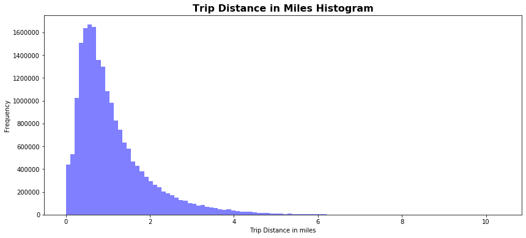

```python
# creating Histogram to assess distribution of Trip Distance which is in miles.
plt.figure(figsize=(14,6))
plt.hist(data=df, x='distance_miles', color='blue',bins = 100, alpha = .5)

plt.xlabel('Trip Distance in miles')
plt.ylabel("Frequency")
plt.title("Trip Distance in Miles Histogram",fontsize = 16, fontweight = 'bold');
```

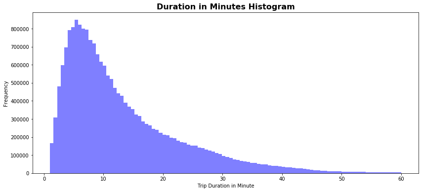

```python
# As distance and duration can be tied back with speed. so creating Duration in minutes histogram to see if some dispereancy is present
plt.figure(figsize=(14,6))
plt.hist(data=df, x='duration_minutes',bins=100, color='blue', alpha = .5)
plt.xlabel('Trip Duration in Minute')
plt.xlabel('Trip Duration in Minute')
plt.ylabel("Frequency")
plt.title("Duration in Minutes Histogram",fontsize = 16, fontweight = 'bold');
```

### it is interested to note that distance_miles is 0 for some users but they have spent some time on bike, Considering it has some malfunction in operating or error I will delet those rows

## Quality 6

### it is interesting to see that some of the distance are 0's while time spent on trip is not 0. So assuming these are errors I am going to reomve these record

### Code

```python
# checking the records where distance in miles is 0
df.query('distance_miles == 0')
```

|  | tripduration | starttime | stoptime | start_station_id | start_station_name | start_station_latitude | start_station_longitude | end_station_id | end_station_name | end_station_latitude | ... | birth_year | gender | distance_miles | start_date | month | day | start_hourofday | user_age | duration_minutes | speed |
| --- | --- | --- | --- | --- | --- | --- | --- | --- | --- | --- | --- | --- | --- | --- | --- | --- | --- | --- | --- | --- | --- |
| 24 | 643 | 2019-01-01 00:24:10.907 | 2019-01-01 00:34:54.295 | 484.0 | W 44 St & 5 Ave | 40.75500 | -73.98014 | 484.0 | W 44 St & 5 Ave | 40.75500 | ... | 1975 | Male | 0.00000 | 2019-01-01 | January | Tuesday | 0 | 45 | 10.71667 | 0.00000 |
| 93 | 468 | 2019-01-01 00:49:05.141 | 2019-01-01 00:56:53.209 | 195.0 | Liberty St & Broadway | 40.70906 | -74.01043 | 195.0 | Liberty St & Broadway | 40.70906 | ... | 1980 | Male | 0.00000 | 2019-01-01 | January | Tuesday | 0 | 40 | 7.80000 | 0.00000 |
| 103 | 714 | 2019-01-01 00:53:25.597 | 2019-01-01 01:05:19.741 | 3171.0 | Amsterdam Ave & W 82 St | 40.78525 | -73.97667 | 3171.0 | Amsterdam Ave & W 82 St | 40.78525 | ... | 1987 | Female | 0.00000 | 2019-01-01 | January | Tuesday | 0 | 33 | 11.90000 | 0.00000 |
| 131 | 64 | 2019-01-01 00:59:30.845 | 2019-01-01 01:00:35.292 | 402.0 | Broadway & E 22 St | 40.74034 | -73.98955 | 402.0 | Broadway & E 22 St | 40.74034 | ... | 1983 | Male | 0.00000 | 2019-01-01 | January | Tuesday | 0 | 37 | 1.06667 | 0.00000 |
| 154 | 2904 | 2019-01-01 01:03:15.092 | 2019-01-01 01:51:39.301 | 487.0 | E 20 St & FDR Drive | 40.73314 | -73.97574 | 487.0 | E 20 St & FDR Drive | 40.73314 | ... | 1963 | Male | 0.00000 | 2019-01-01 | January | Tuesday | 1 | 57 | 48.40000 | 0.00000 |
| ... | ... | ... | ... | ... | ... | ... | ... | ... | ... | ... | ... | ... | ... | ... | ... | ... | ... | ... | ... | ... | ... |
| 20551604 | 693 | 2019-12-31 23:39:16.375 | 2019-12-31 23:50:49.945 | 2009.0 | Catherine St & Monroe St | 40.71117 | -73.99683 | 2009.0 | Catherine St & Monroe St | 40.71117 | ... | 1961 | Male | 0.00000 | 2019-12-31 | December | Tuesday | 23 | 59 | 11.55000 | 0.00000 |
| 20551632 | 3494 | 2019-12-31 23:44:13.774 | 2020-01-01 00:42:28.163 | 3376.0 | E 65 St & 2 Ave | 40.76472 | -73.96222 | 3376.0 | E 65 St & 2 Ave | 40.76472 | ... | 1969 | Unknown | 0.00000 | 2019-12-31 | December | Tuesday | 23 | 51 | 58.23333 | 0.00000 |
| 20551644 | 1469 | 2019-12-31 23:45:27.021 | 2020-01-01 00:09:56.756 | 3674.0 | Jay St & York St | 40.70140 | -73.98673 | 3674.0 | Jay St & York St | 40.70140 | ... | 1978 | Male | 0.00000 | 2019-12-31 | December | Tuesday | 23 | 42 | 24.48333 | 0.00000 |
| 20551646 | 3023 | 2019-12-31 23:45:56.006 | 2020-01-01 00:36:19.991 | 3712.0 | W 35 St & Dyer Ave | 40.75469 | -73.99740 | 3712.0 | W 35 St & Dyer Ave | 40.75469 | ... | 1991 | Female | 0.00000 | 2019-12-31 | December | Tuesday | 23 | 29 | 50.38333 | 0.00000 |
| 20551674 | 1357 | 2019-12-31 23:51:18.276 | 2020-01-01 00:13:56.184 | 2021.0 | W 45 St & 8 Ave | 40.75929 | -73.98860 | 2021.0 | W 45 St & 8 Ave | 40.75929 | ... | 1991 | Female | 0.00000 | 2019-12-31 | December | Tuesday | 23 | 29 | 22.61667 | 0.00000 |

407454 rows × 23 columns

```python
# Extracting only records where distance in miles not equal to 0
df = df.query('distance_miles != 0')
```

### Test

```python
# veryfying if all records where distance was equal to 0 have been removed
len(df.query('distance_miles == 0'))
```

```
0
```

#### duration_minutes, distance_miles seems to be right skewed, but we verified that based on speed this data is right. So I decided to keeps this rows in Analysis

### Saving cleaned data to csv file

```python
# Copy clean data to csv
#df.to_csv('Ny_2019_master_distance_cleaned.csv', index = False)
```

```python
#df1 = pd.read_csv('Ny_2019_master_distance_cleaned.csv')
```

```python
#df1.shape
```

```python
#df1.info()
```

#### Based on Assesing process above, I think that main features on which I would like to focus my analysis are:

> start_date, month, day, start_hourofday extracted from starttime, as these can be used to calculate when bikes are in high or low demand.

> User Type, gender, user_age are also important features to study about different users behaviours. distance_miles, duration_minutes are the measures that can be used to get meaningful analysis

### Features in the dataset I think will help support my investigation:

> Start time, duration, distance and user related information will be very useful for further analysis

#### For further Analysis keeping my computer performance in considereation, I will bring Columns which I have identified for further analysis into new DataFrame for **Univariate Exploration**

```python
# Creating list for column that are needed for further analysis
columns = ['bikeid','start_station_name', 'end_station_name','start_date', 'month', 'day', 'start_hourofday','usertype','gender','user_age','distance_miles', 'duration_minutes', 'speed']
```

```python
# creating new Dataframe with columns identified above
df_analysis = df[columns]
```

```python
#veryfying if extra columns are removed using shape function
df_analysis.shape
```

```
(19884919, 13)
```

```python
# using describe function to double check the data types
df_analysis.info()
```

```
<class 'pandas.core.frame.DataFrame'>
Int64Index: 19884919 entries, 0 to 20551696
Data columns (total 13 columns):
 #   Column              Dtype
---  ------              -----
 0   bikeid              object
 1   start_station_name  object
 2   end_station_name    object
 3   start_date          datetime64[ns]
 4   month               object
 5   day                 object
 6   start_hourofday     int64
 7   usertype            category
 8   gender              category
 9   user_age            int64
 10  distance_miles      float64
 11  duration_minutes    float64
 12  speed               float64
dtypes: category(2), datetime64[ns](1), float64(3), int64(2), object(5)
memory usage: 1.8+ GB
```

## univariate Analysis

#### After data is cleaned and all imported features are extracted into df_analysis. I will start looking into distribution of different features applying Univariate Analysis

#### Exploring distribution of User_age first

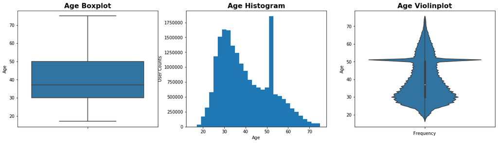

```python
# Exploring User Age Statistics using different charts such as boxplot, histogram, and violin plot
plt.figure(figsize = [20, 5])

plt.subplot(1,3,1)
sb.boxplot(data = df_analysis, y = 'user_age')
plt.ylabel("Age")
plt.title("Age Boxplot",fontsize = 16, fontweight = 'bold');

plt.subplot(1, 3, 2)
bins = np.arange(df_analysis.user_age.min()-2, df.user_age.max()+2,2)
plt.hist(df_analysis.user_age, bins = bins)
plt.xlabel("Age")
plt.ylabel("User Counts")
plt.title("Age Histogram",fontsize = 16, fontweight = 'bold');

plt.subplot(1, 3, 3)
sb.violinplot(data = df_analysis, y = 'user_age')
plt.ylabel("Age")
plt.xlabel("Frequency")
plt.title("Age Violinplot",fontsize = 16, fontweight = 'bold');
```

### TThere seems to be high unusual frequency in Age from above statistics charts between 50 to 55 years of Age

```python
# creating datframe ofor user aged 49 to 70 years
user_50_60 = df_analysis.query('user_age > 49 and user_age < 70')
```

```python
# Displaying user_50_60 dataframe
user_50_60
```

|  | bikeid | start_station_name | end_station_name | start_date | month | day | start_hourofday | usertype | gender | user_age | distance_miles | duration_minutes | speed |
| --- | --- | --- | --- | --- | --- | --- | --- | --- | --- | --- | --- | --- | --- |
| 1 | 32723 | Pershing Square North | E 39 St & 2 Ave | 2019-01-01 | January | Tuesday | 0 | Subscriber | Male | 56 | 0.35898 | 5.26667 | 4.08964 |
| 17 | 35785 | Amsterdam Ave & W 82 St | Columbus Ave & W 72 St | 2019-01-01 | January | Tuesday | 0 | Subscriber | Male | 66 | 0.57860 | 58.23333 | 0.59615 |
| 18 | 32106 | Central Park West & W 72 St | Central Park W & W 96 St | 2019-01-01 | January | Tuesday | 0 | Subscriber | Unknown | 51 | 1.22353 | 13.81667 | 5.31330 |
| 23 | 32313 | W 21 St & 6 Ave | 9 Ave & W 22 St | 2019-01-01 | January | Tuesday | 0 | Subscriber | Female | 52 | 0.48456 | 6.28333 | 4.62713 |
| 27 | 24945 | Central Park West & W 68 St | 8 Ave & W 33 St | 2019-01-01 | January | Tuesday | 0 | Customer | Unknown | 51 | 1.72945 | 19.08333 | 5.43757 |
| ... | ... | ... | ... | ... | ... | ... | ... | ... | ... | ... | ... | ... | ... |
| 20551682 | 30028 | W 4 St & 7 Ave S | W Broadway & W Houston St | 2019-12-31 | December | Tuesday | 23 | Subscriber | Male | 59 | 0.54300 | 22.63333 | 1.43948 |
| 20551684 | 39429 | E 81 St & York Ave | Madison Ave & E 82 St | 2019-12-31 | December | Tuesday | 23 | Customer | Unknown | 51 | 0.67317 | 7.98333 | 5.05934 |
| 20551688 | 18317 | Macon St & Nostrand Ave | Monroe St & Bedford Ave | 2019-12-31 | December | Tuesday | 23 | Subscriber | Male | 53 | 0.34855 | 3.21667 | 6.50139 |
| 20551691 | 41688 | E 13 St & Avenue A | W 43 St & 10 Ave | 2019-12-31 | December | Tuesday | 23 | Subscriber | Male | 55 | 2.22533 | 30.63333 | 4.35864 |
| 20551696 | 21013 | E 102 St & 1 Ave | E 103 St & Lexington Ave | 2019-12-31 | December | Tuesday | 23 | Subscriber | Unknown | 51 | 0.38456 | 5.16667 | 4.46588 |

5025082 rows × 13 columns

```python
# using pandas valu_counts function to see the user ditribution who are between 50 to 70 years of age
user_50_60.user_age.value_counts()
```

```
51    1567192
50     341275
52     287181
53     281384
55     262312
54     261795
56     255136
57     237665
58     226568
60     197885
59     192225
61     163926
62     145353
63     130084
64     120003
65      95759
66      87989
67      76780
68      47986
69      46584
Name: user_age, dtype: int64
```

### Data is cleaned in above processes, after data cleaning, we can see that the number of users in age range of 51 - 53 are maximum. Data is not distributed evenly. Data is right Skewed with user declining after age of 60 years old

### #nothing suspicios seems to be in age column. Older people can also be user

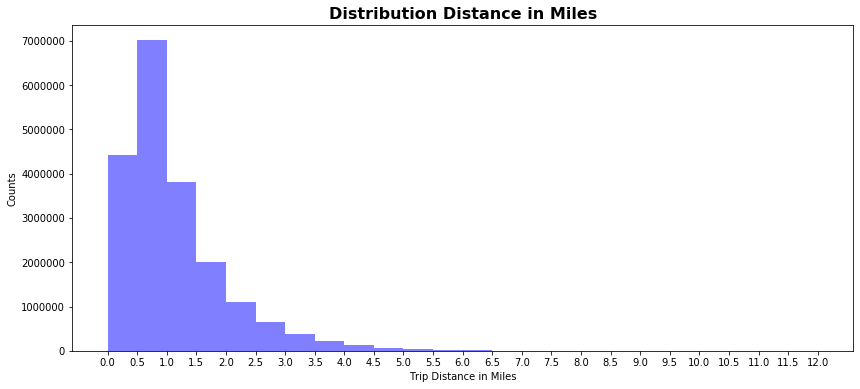

```python
# Exploring distribution of Distance covered by users using histogram chart. This is step perofmed as univariate analysis
plt.figure(figsize=(14,6))
bins = np.arange(0, df_analysis.distance_miles.max()+2, .5)
ticks = np.arange(0, df_analysis.distance_miles.max()+2, .5)
plt.hist(data=df, x='distance_miles', bins=bins, color='blue', alpha = .5)
plt.xticks(ticks);
plt.xlabel('Trip Distance in Miles')
plt.ylabel('Counts')
plt.title('Distribution Distance in Miles',fontsize = 16, fontweight = 'bold');
```

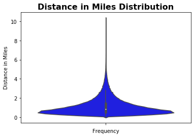

```python
# Exploring distribution of Distance covered by users using Viloin chart. This is step perofmed as univariate analysis
sb.violinplot(data = df_analysis, y = 'distance_miles', color = 'blue', alpha=.5)
plt.xlabel('Frequency')
plt.ylabel('Distance in Miles')
plt.title('Distance in Miles Distribution',fontsize = 16, fontweight = 'bold');
```

### Dustribution of distance in miles is right skewed. A large number of users drive bi cycle from range o .5 miles to 1 miles.

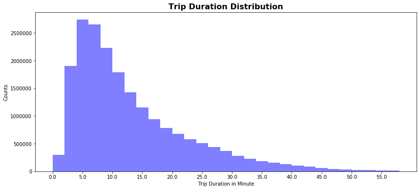

```python
# Exploring distribution of Trip Duration using Viloin chart. This is step perofmed as univariate analysis
plt.figure(figsize=(14,6))
bins = np.arange(0, df.duration_minutes.max(), 2)
ticks = np.arange(0, df.duration_minutes.max(), 5)
plt.hist(data=df, x='duration_minutes', bins=bins, color='blue', alpha = .5)
plt.xticks(ticks, ticks);
plt.xlabel('Trip Duration in Minute')
plt.ylabel('Counts')
plt.title('Trip Duration Distribution',fontsize = 16, fontweight = 'bold');
```

### So as we have seen during Data Cleaning process, Although duration in Minutes, and distance in Miles data for users seems to be right skewed, still it is accurate based on users speed miles/hr. Normal user have maximum speed of 26 miles/hours, and data that is out of this range has been already removed in data cleaning process. So I will go ahead with now in my further analysis

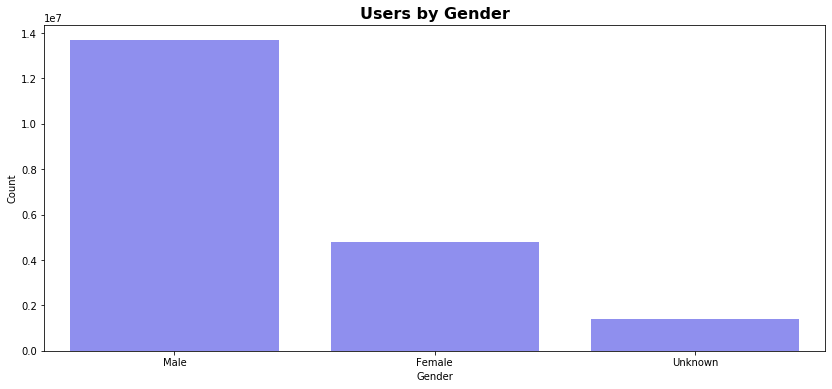

```python
# Creating chart to see how users are distributed by gender
plt.figure(figsize=(14,6))
gender_value = df_analysis.gender.value_counts().index
sb.countplot(data=df_analysis, x='gender', color="blue", alpha =.5, order =gender_value );
plt.xlabel('Gender');
plt.ylabel('Count')
plt.title('Users by Gender',fontsize = 16, fontweight = 'bold');
```

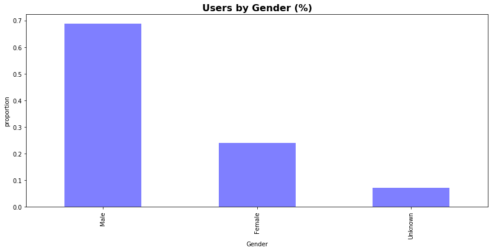

```python
# creating proprtion chart by user's gender
plt.figure(figsize=(14,6))
df_analysis['gender'].value_counts(normalize=True).plot(kind='bar', color = 'blue', alpha = .5)
plt.xlabel('Gender')
plt.ylabel('proportion')
plt.title('Users by Gender (%)',fontsize = 16, fontweight = 'bold');
```

## A large number of users in our data are Male with around 70% of total users

```python
# using value_counts function of pandas to see usertype
df_analysis['usertype'].value_counts()
```

```
Subscriber    17283527
Customer       2601392
Name: usertype, dtype: int64
```

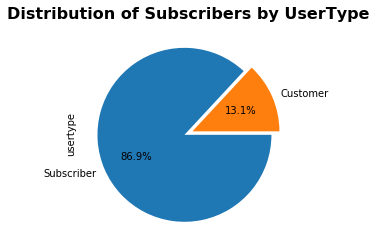

```python
ax=df_analysis.usertype.value_counts().plot.pie(explode = (0.05,0.05),autopct='%1.1f%%',counterclock = False)
plt.title('Distribution of Subscribers by UserType',fontsize = 16, fontweight = 'bold');
```

### There are two types of User types, Customers and Subscribers. A large number of users in our data are Subscriber than customer with around 87% of total users

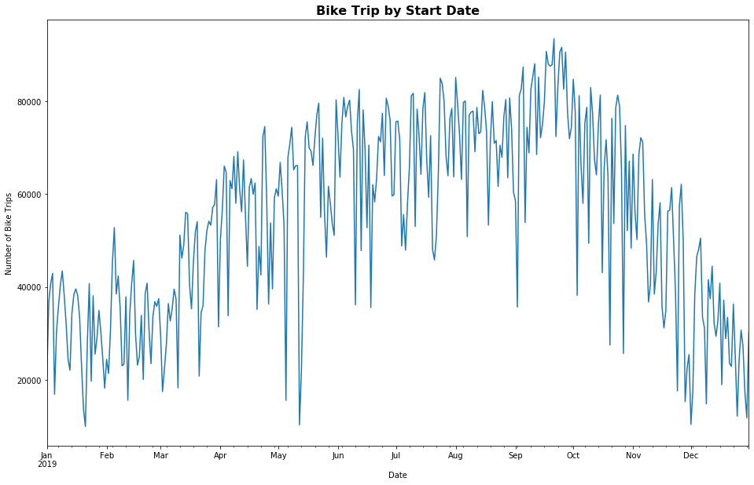

```python
# Creating line chart to see bike usage trend
plt.figure(figsize=(16,10))
df_analysis.groupby('start_date')['bikeid'].count().plot(kind ='line')
plt.xlabel('Date');
plt.ylabel('Number of Bike Trips')
plt.title('Bike Trip by Start Date',fontsize = 16, fontweight = 'bold');
```

```python
# creating a list of week days that will be used for ordering chart later
cats = [ 'Monday', 'Tuesday', 'Wednesday', 'Thursday', 'Friday', 'Saturday', 'Sunday']
```

```python
# creating a list ofMonths that will be used for ordering chart later
cats_mth = [ 'January', 'February', 'March', 'April', 'May', 'June', 'July', 'August', 'September', 'October', 'November','December']
```

### After checking the trend, I am going to analyze by months

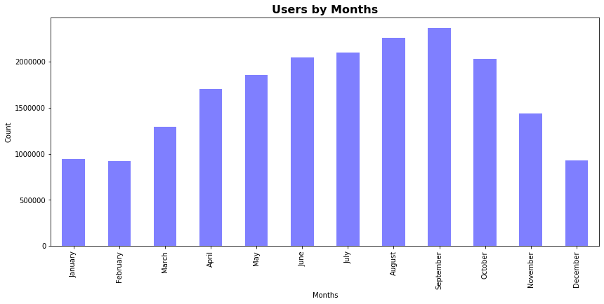

```python
# creating bar to see bike uage by Months
plt.figure(figsize=(14,6))
df_analysis.groupby('month')['bikeid'].count().reindex(cats_mth).plot(kind ='bar', color = 'blue', alpha=.5)
plt.xlabel('Months');
plt.ylabel('Count')
plt.title('Users by Months',fontsize = 16, fontweight = 'bold');
```

### As expected most of the trip was made during Summer and Fall time, as New york get very cold during winter.

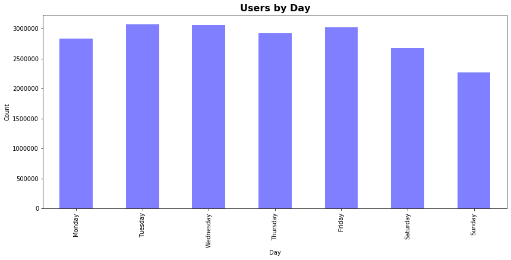

```python
# creating bar to see bike uage by Week Days
plt.figure(figsize=(14,6))
df_analysis.groupby('day')['bikeid'].count().reindex(cats).plot(kind ='bar',color = 'blue', alpha =.5)
plt.xlabel('Day');
plt.ylabel('Count')
plt.title('Users by Day',fontsize = 16, fontweight = 'bold');
```

### Tuesday and wednesday is the most busy day, while weekends are the less. I assume people mostly use bicycle to commute to work and come back to home. We will see it in more detail below

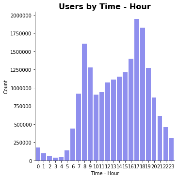

```python
# creating bar to see bike uage by hours of day
plt.figure(figsize=(20, 6))
sb.catplot(data = df_analysis, x='start_hourofday', kind='count', color="blue", alpha=.5)
plt.xlabel('Time - Hour');
plt.ylabel('Count')
plt.title('Users by Time - Hour',fontsize = 16, fontweight = 'bold');
```

### There are two peaks in bicycle use . first around 7 am to 9 am and other from 5 pm to 7 pm. Which made my assumption more strong that people in New york use rental bicycle for work commute

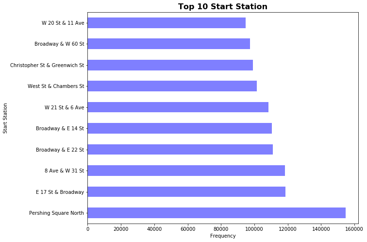

```python
# creating bar to see bike frequency by start station
plt.figure(figsize=(10, 8))
ax = df_analysis.start_station_name.value_counts().sort_values(ascending =False)[:10].plot(kind='barh',color="blue",alpha=.5)
plt.title('Top 10 Start Station',fontsize = 16, fontweight = 'bold')
ax.set_xlabel('Frequency')
ax.set_ylabel("Start Station");
```

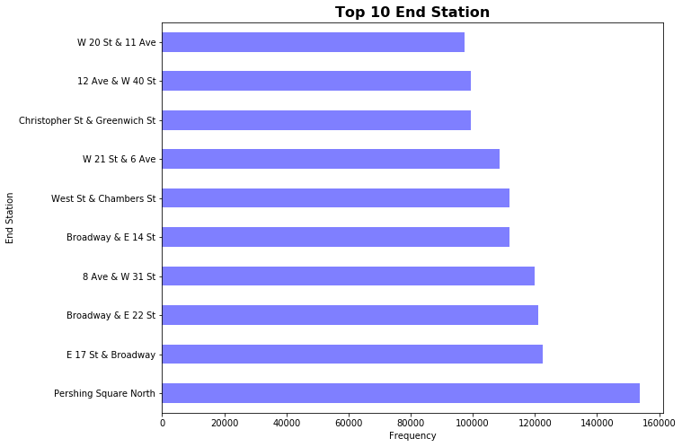

```python
# creating bar to see bike frequency by End station
plt.figure(figsize=(10, 8))
ax = df_analysis.end_station_name.value_counts().sort_values(ascending =False)[:10].plot(kind='barh',color="blue",alpha=.5)
plt.title('Top 10 End Station',fontsize = 16, fontweight = 'bold')
ax.set_xlabel('Frequency')
ax.set_ylabel("End Station");
```

## Bivariate Exploration

> In this section, investigate relationships between pairs of variables in your data. Make sure the variables that you cover here have been introduced in some fashion in the previous section (univariate exploration).

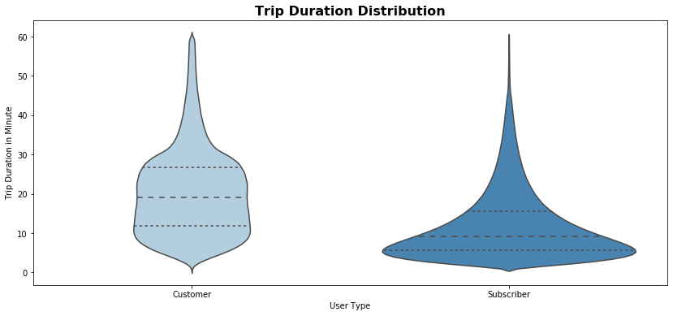

```python
# Creating Violin Chart to see distribution of user type by duration of minutes
plt.figure(figsize=(14,6))
sb.violinplot(data=df_analysis, x='usertype', y='duration_minutes', palette='Blues',inner='quartile');
plt.xlabel('User Type');
plt.ylabel('Trip Duration in Minute')
plt.title('Trip Duration Distribution',fontsize = 16, fontweight = 'bold');
```

### The median of trip duration distribution is much narrower for subscribers compared to casual riders on the shorter/quicker trip end overall. It seems like subscribers have a more specific usage or targeted goal riding the bikes compared to customers who vary more and generally rented the bikes for longer.

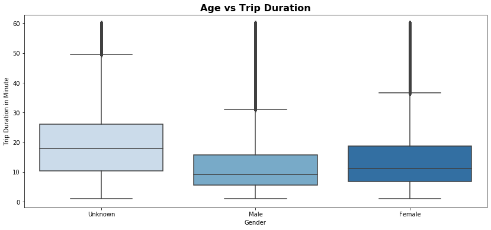

```python
# Creating boxplot Chart to see distribution of user type by duration of minutes
plt.figure(figsize=(14,6))
sb.boxplot(data=df_analysis, x='gender', y = 'duration_minutes', palette='Blues')
plt.title("Age vs Trip Duration",fontsize = 16, fontweight = 'bold')
plt.xlabel("Gender")
plt.ylabel('Trip Duration in Minute');
```

### Though not a huge difference, male riders tend to have shorter trips compared to female users, indicated by both a smaller median and shorter IQR.

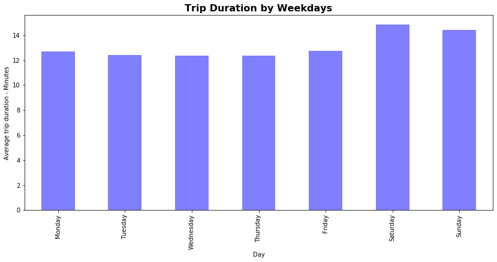

```python
# creating bar chart to see trip duration in minutes by week days
plt.figure(figsize=(14,6))
df_analysis.groupby('day')['duration_minutes'].mean().reindex(cats).plot(kind ='bar',color = 'blue', alpha =.5)
plt.xlabel('Day');
plt.ylabel('Average trip duration - Minutes')
plt.title('Trip Duration by Weekdays',fontsize = 16, fontweight = 'bold');
```

### Users spent more time on bikes on weekends as compared to weekdays. In next part I will analyse duration based on users type

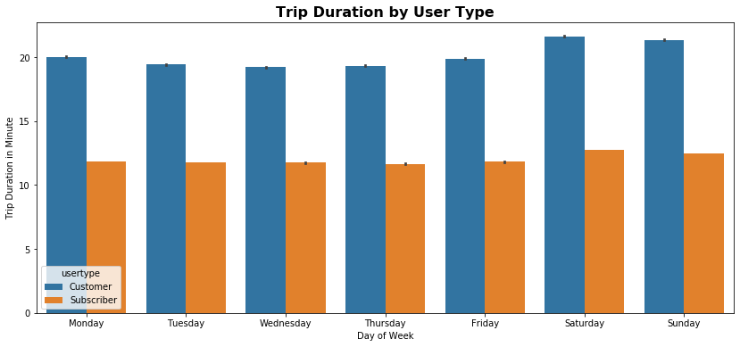

```python
# creating bar chart to see trip duration in minutes by week days by user type
plt.figure(figsize=(14,6))
sb.barplot(data=df_analysis, x='day', y='duration_minutes',hue='usertype', order = cats);
plt.xlabel('Day of Week');
plt.ylabel('Trip Duration in Minute')
plt.title('Trip Duration by User Type',fontsize = 16, fontweight = 'bold');
```

### On further analysis we can see that on weekends trip duration has increased for both users and subscribers. Although difference is not very significant

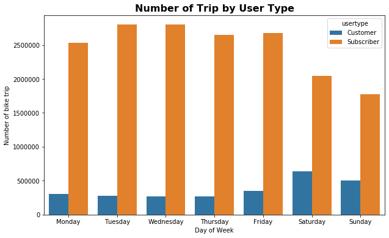

```python
# creating bar chart to see number of bikes checked out by week days by user type
plt.subplots(figsize=(10, 6))
sb.countplot(data=df_analysis, x='day', hue='usertype', order = cats);
plt.xlabel('Day of Week');
plt.ylabel('Number of bike trip')
plt.title('Number of Trip by User Type',fontsize = 16, fontweight = 'bold');
```

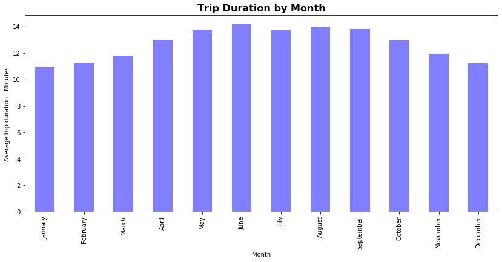

```python
# creating bar chart to see trip duration in minutes by Months
plt.figure(figsize=(14,6))
df_analysis.groupby('month')['duration_minutes'].mean().reindex(cats_mth).plot(kind ='bar',color = 'blue', alpha =.5)
plt.xlabel('Month');
plt.ylabel('Average trip duration - Minutes')
plt.title('Trip Duration by Month',fontsize = 16, fontweight = 'bold');
```